# Explanatory Analysis of Ford GoBike Trip Data

## by Manish Kumar

## Investigation Overview

> The main goal of this presentation is to highlight the key findings of the analysis of Ford GoBike share trip data.

## Dataset Overview

> Ford GoBike is bicycle sharing service operational in San Francisco Bay Area.It began operation in June 28, 2017.The company provides bike trip information for data analysis perposes. For the current analysis, I have selected one year data from January, 2018 to December 2018.The dataset contains 16 columns and 18,63,721 rows. We have some key insights from this dataset in coming slides.

## 1. The most busiest station - San Francisco Caltrain Station 2(Townsend St at 4th St)

> "San Francisco Caltrain Station 2(Townsend St at 4th St)" is the busiest one.The analysis is based on the most number of incoming and outgoing rides to or from a station.

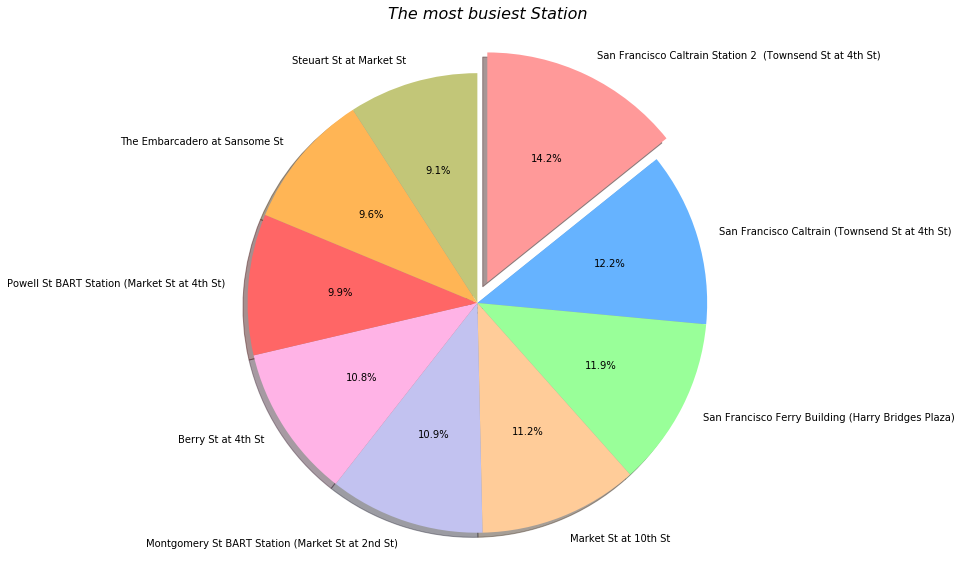

```python
pie_data=(gobike.start_station_name.value_counts().nlargest(10)+\
          gobike.end_station_name.value_counts().nlargest(10)).nlargest(10)
explode = (0.1, 0, 0, 0,0, 0, 0, 0,0)
colors = ['#ff9999','#66b3ff','#99ff99','#ffcc99','#c2c2f0','#ffb3e6', '#ff6666','#ffb555', '#c2c678','#ff8888']
fig,ax=plt.subplots(figsize=(10,8))
ax.pie(pie_data,explode=explode,autopct='%1.1f%%',labels=pie_data.index,startangle=90,\
          counterclock=False,shadow=True,colors=colors);
ax.axis('square')
plt.title("The most busiest Station",fontsize=16,loc='center',pad=10.0,style='italic');
plt.tight_layout()
```

## 2. The Relation: Trip Duration Vs Trip Distance.

> There is a linear relation with positive slope between trip distance and trip duration as shown by regression line. This means for majority of trips, which are of longer distance more time is taken.This also shows the the distance calculated using latitude and longitude is quite reaosnable.However, for same distance customers have taken longer trip time compared to Subscribers. One possible reason might be that Customers are using this explore the city rather than for daily works.A possbile further analysis would be to see effect of categorical variable(Gender, Age, Time, User Type) on this relation.

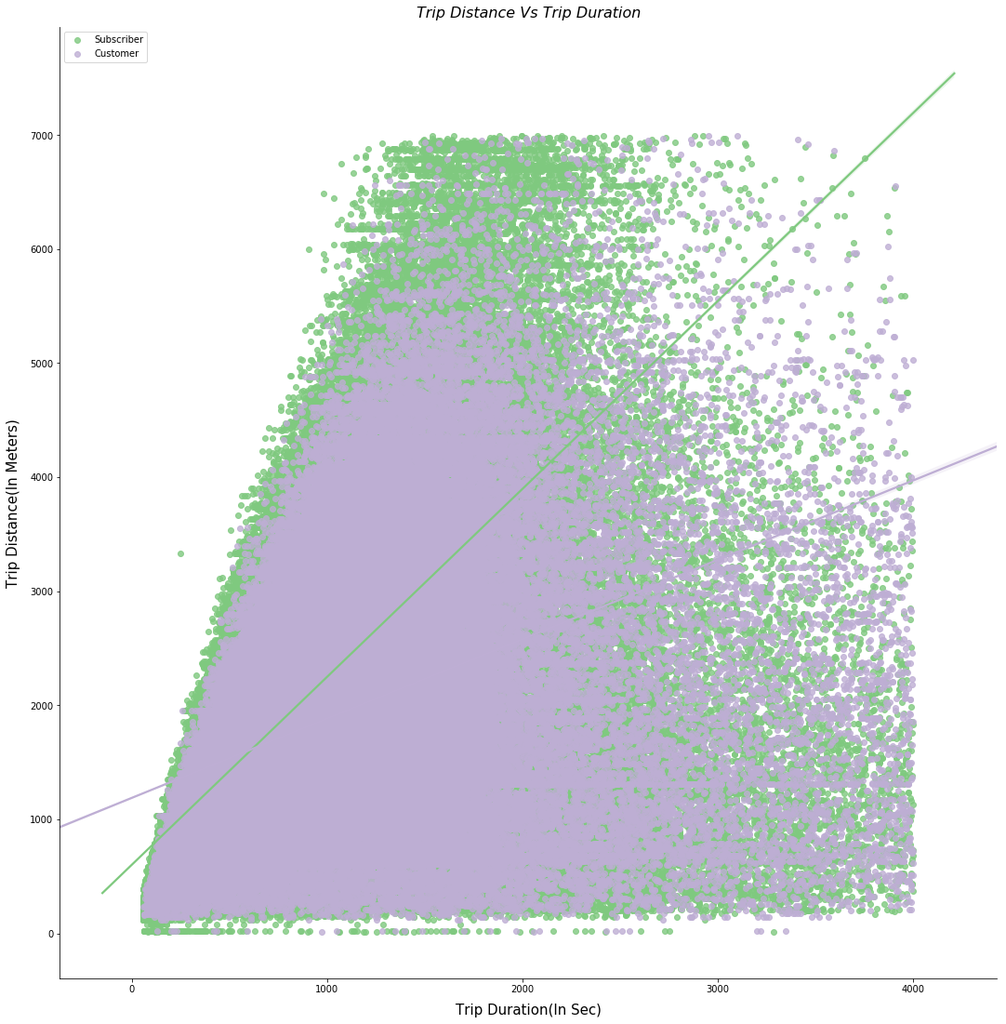

```python
gobike['distance_m']=gobike['distance_km']*1000
sb.lmplot(x='duration_sec',y='distance_m',hue='user_type',size=15,data=gobike,palette='Accent',legend=False);
plt.xlabel("Trip Duration(In Sec)",fontsize=15,labelpad=10);
plt.ylabel("Trip Distance(In Meters)",fontsize=15,labelpad=10);
plt.title("Trip Distance Vs Trip Duration",fontsize=16,loc='center',pad=10.0,style='italic');
plt.legend(loc=2);
```

## 3. How is response of the program Bike for share for All?

> Bike share for All is an unique program launched by Ford Gobike syatem. Bike Share for All provides a one-time $5 annual membership for qualifying residents. The program also includes a cash payment option for those who do not have a debit or credit card. As per website eligibility to enroll this program is "Bike Share for All is available to Bay Area residents ages 18 and older who qualify for Calfresh, SFMTA (Low Income) Lifeline Passes or PG&E CARE utility discount." I can see Bike_share_for_All subscribers have different trends than normal subscribers.Bike_share_for_All subscribers are more likely use this system in the afternoon or evening compared to normal subscribers which prefer morning time.

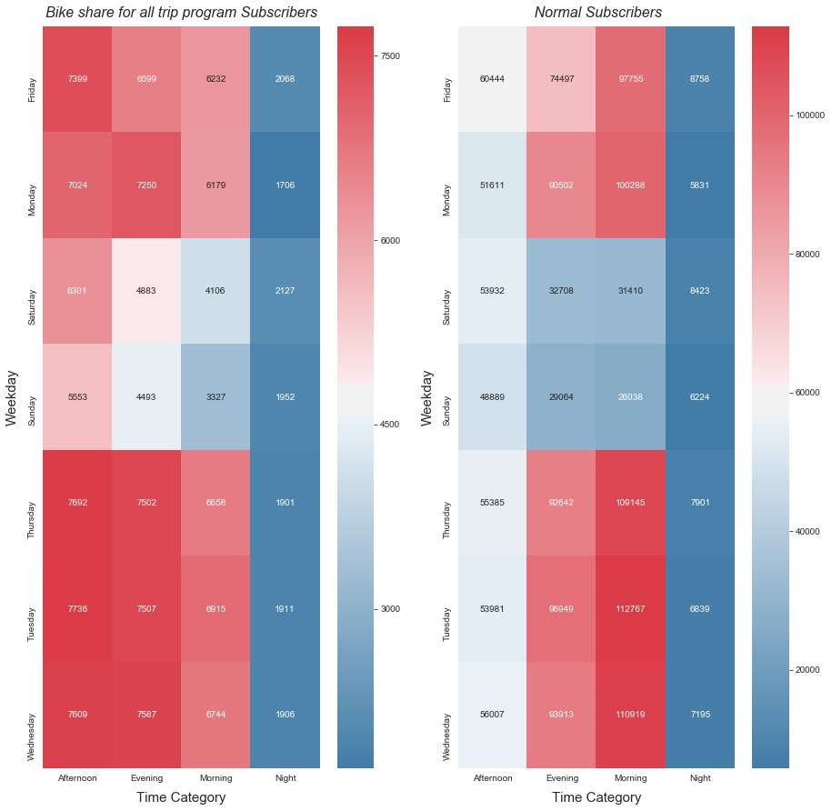

```python
plt.figure(figsize=(15,15))
sb.set_style("white")
gobike_yes=gobike.query('bike_share_for_all_trip=="Yes"')
gobike_no=gobike.query('bike_share_for_all_trip=="No"')
pivot_yes=pd.pivot_table(gobike_yes,index='weekday',columns='time_category',values='bike_id',aggfunc='count');
pivot_no=pd.pivot_table(gobike_no,index='weekday',columns='time_category',values='bike_id',aggfunc='count');
cmap = sb.diverging_palette(240, 10, as_cmap=True);
plt.subplot(121)
sb.heatmap(pivot_yes,annot=True,cmap=cmap,fmt='.0f',annot_kws={'size':10});
plt.xlabel("Time Category",fontsize=15,labelpad=10)
plt.ylabel("Weekday",fontsize=15,labelpad=10)
plt.title("Bike share for all trip program Subscribers",fontsize=16,loc='center',pad=10.0,style='italic');
plt.subplot(122)
sb.heatmap(pivot_no,annot=True,cmap=cmap,fmt='.0f',annot_kws={'size':10});
plt.xlabel("Time Category",fontsize=15,labelpad=10)
plt.ylabel("Weekday",fontsize=15,labelpad=10)
plt.title(" Normal Subscribers",fontsize=16,loc='center',pad=10.0,style='italic');
```

## 4. Trends of trip count based on Gender, User Type, Age Group and Time Category

> This is sort of summarisation of key findings in previous analysis and reinforce it. At day level, if I see then Morning, Evening and Afternoon are pick time. If I see age wise the millenials(18-34) are major section which are using bike share service. Now moving to user type, Subscribers those belongs to millenials age group are using the bike share service most and their pick time is morning and evening. This trends is persist in further classication on gender basis. In contrast, Most Customers belongs to millenials age group but pick time is evening and afternoon.This trends is persist in further classication on gender basis.

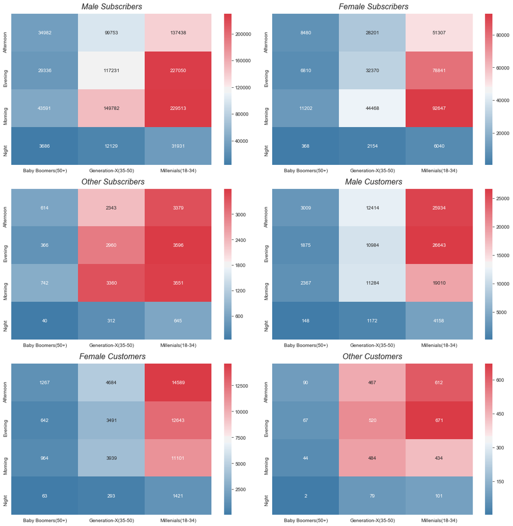

```python
plt.figure(figsize=(15,15))
sb.set_style("white")
gobike_sub_male=gobike.query('user_type=="Subscriber" and member_gender=="Male"')
gobike_sub_female=gobike.query('user_type=="Subscriber" and member_gender=="Female"')
gobike_sub_other=gobike.query('user_type=="Subscriber" and member_gender=="Other"')
gobike_cus_male=gobike.query('user_type=="Customer" and member_gender=="Male"')
gobike_cus_female=gobike.query('user_type=="Customer" and member_gender=="Female"')
gobike_cus_other=gobike.query('user_type=="Customer" and member_gender=="Other"')

pivot_sub_male=pd.pivot_table(gobike_sub_male,index='time_category',columns='age_group',values='bike_id',aggfunc='count');
pivot_sub_female=pd.pivot_table(gobike_sub_female,index='time_category',columns='age_group',values='bike_id',aggfunc='count');
pivot_sub_other=pd.pivot_table(gobike_sub_other,index='time_category',columns='age_group',values='bike_id',aggfunc='count');
pivot_cus_male=pd.pivot_table(gobike_cus_male,index='time_category',columns='age_group',values='bike_id',aggfunc='count');
pivot_cus_female=pd.pivot_table(gobike_cus_female,index='time_category',columns='age_group',values='bike_id',aggfunc='count');
pivot_cus_other=pd.pivot_table(gobike_cus_other,index='time_category',columns='age_group',values='bike_id',aggfunc='count');

cmap = sb.diverging_palette(240, 10, as_cmap=True);
plt.subplot(321)
sb.heatmap(pivot_sub_male,annot=True,cmap=cmap,fmt='.0f',annot_kws={'size':10});
plt.xlabel("",fontsize=15,labelpad=10)
plt.ylabel("",fontsize=15,labelpad=10)
plt.title("Male Subscribers",fontsize=16,loc='center',pad=10.0,style='italic');

plt.subplot(322)
sb.heatmap(pivot_sub_female,annot=True,cmap=cmap,fmt='.0f',annot_kws={'size':10});
plt.xlabel("",fontsize=15,labelpad=10)
plt.ylabel("",fontsize=15,labelpad=10)
plt.title(" Female Subscribers",fontsize=16,loc='center',pad=10.0,style='italic');

plt.subplot(323)
sb.heatmap(pivot_sub_other,annot=True,cmap=cmap,fmt='.0f',annot_kws={'size':10});
plt.xlabel("",fontsize=15,labelpad=10)
plt.ylabel("",fontsize=15,labelpad=10)
plt.title(" Other Subscribers",fontsize=16,loc='center',pad=10.0,style='italic');

plt.subplot(324)
sb.heatmap(pivot_cus_male,annot=True,cmap=cmap,fmt='.0f',annot_kws={'size':10});
plt.xlabel("",fontsize=15,labelpad=10)
plt.ylabel("",fontsize=15,labelpad=10)
plt.title(" Male Customers",fontsize=16,loc='center',pad=10.0,style='italic');

plt.subplot(325)
sb.heatmap(pivot_cus_female,annot=True,cmap=cmap,fmt='.0f',annot_kws={'size':10});
plt.xlabel("",fontsize=15,labelpad=10)
plt.ylabel("",fontsize=15,labelpad=10)
plt.title(" Female Customers",fontsize=16,loc='center',pad=10.0,style='italic');

plt.subplot(326)
sb.heatmap(pivot_cus_other,annot=True,cmap=cmap,fmt='.0f',annot_kws={'size':10});
plt.xlabel("",fontsize=15,labelpad=10)
plt.ylabel("",fontsize=15,labelpad=10)
plt.title("Other Customers",fontsize=16,loc='center',pad=10.0,style='italic');
plt.tight_layout()
```